# Homework 3 [PSTAT 131]

### Question 4

Create a training set including the predictors `pclass`, `sex`, `age`, `sib_sp`, `parch` and `fare`:

```r
titanic_recipe <- recipe(survived ~ pclass + sex + age + sib_sp + parch + fare, data = titanic_train) %>%
  step_impute_linear(age) %>% # Deal with missing values in `age` variable
  step_dummy(all_nominal_predictors()) %>% # ecode categorical predictors
  step_interact(~sex:fare) %>% # interaction between sex and passenger fare
  step_interact(~age:fare) # interaction between age and passenger fare
```

### Question 5

Specify a **logistic regression** model, create a workflow and apply workflow to training data:

```r
log_reg <- logistic_reg() %>%
  set_engine("glm") %>%
  set_mode("classification")

log_wkflow <- workflow() %>%
  add_model(log_reg) %>%
  add_recipe(titanic_recipe)

log_fit <- fit(log_wkflow, titanic_train)
```

### Question 6

Specify a **LDA** model, create a workflow and apply workflow to training data:

```r
lda_mod <- discrim_linear() %>%
  set_mode("classification") %>%
  set_engine("MASS")

lda_wkflow <- workflow() %>%
  add_model(lda_mod) %>%
  add_recipe(titanic_recipe)

lda_fit <- fit(lda_wkflow, titanic_train)
```

### Question 7

Specify a **QDA** model, create a workflow and apply workflow to training data:

```r
qda_mod <- discrim_quad() %>%
  set_mode("classification") %>%
  set_engine("MASS")

qda_wkflow <- workflow() %>%
  add_model(qda_mod) %>%
  add_recipe(titanic_recipe)

qda_fit <- fit(qda_wkflow, titanic_train)
```

### Question 8

Specify a **Naive Bayes** model, create a workflow and apply workflow to training data:

```r
nb_mod <- naive_Bayes() %>%
  set_mode("classification") %>%
  set_engine("klaR") %>%
  set_args(usekernel = FALSE)

nb_wkflow <- workflow() %>%
  add_model(nb_mod) %>%
  add_recipe(titanic_recipe)

nb_fit <- fit(nb_wkflow, titanic_train)
```

### Question 9

Fit the models to the training data and find which model achieved the highest accuracy on the training data.

#### Logistic Regression:

```r
predict(log_fit, new_data = titanic_train)
```

```
## # A tibble: 623 × 1
##    .pred_class
##    <fct>
##  1 No
##  2 No
##  3 No
##  4 No
##  5 No
##  6 Yes
##  7 No
##  8 No
##  9 Yes
## 10 No
## # … with 613 more rows
```

```r
augment(log_fit, new_data = titanic_train) %>%
  conf_mat(truth = survived, estimate = .pred_class)
```

```
##           Truth
## Prediction Yes  No
##        Yes 171  49
##        No   68 335
```

```r
log_acc <- augment(log_fit, new_data = titanic_train) %>%
  accuracy(truth = survived, estimate = .pred_class)
```

#### LDA:

```r
predict(lda_fit, new_data = titanic_train)
```

```
## # A tibble: 623 × 1
##    .pred_class
##    <fct>
##  1 No
##  2 No
##  3 No
##  4 No
##  5 No
##  6 Yes
##  7 No
##  8 Yes
##  9 Yes
## 10 No
## # … with 613 more rows
```

```r
augment(lda_fit, new_data = titanic_train) %>%
  conf_mat(truth = survived, estimate = .pred_class)
```

```
##           Truth
## Prediction Yes  No
##        Yes 163  52
##        No   76 332
```

```r
lda_acc <- augment(lda_fit, new_data = titanic_train) %>%
  accuracy(truth = survived, estimate = .pred_class)
```

#### QDA:

```r
predict(qda_fit, new_data = titanic_train)
```

```
## # A tibble: 623 × 1
##    .pred_class
##    <fct>
##  1 No
##  2 No
##  3 No
##  4 No
##  5 No
##  6 Yes
##  7 No
##  8 Yes
##  9 No
## 10 Yes
## # … with 613 more rows
```

```r
augment(qda_fit, new_data = titanic_train) %>%
  conf_mat(truth = survived, estimate = .pred_class)
```

```
##           Truth
## Prediction Yes  No
##        Yes 172  62
##        No   67 322
```

```r
qda_acc <- augment(qda_fit, new_data = titanic_train) %>%
  accuracy(truth = survived, estimate = .pred_class)
```

#### Naive Bayes:

```r
predict(nb_fit, new_data = titanic_train)
```

```
## # A tibble: 623 × 1
##    .pred_class
##    <fct>
##  1 No
##  2 No
##  3 No
##  4 No
##  5 No
##  6 Yes
##  7 No
##  8 No
##  9 No
## 10 Yes
## # … with 613 more rows
```

```r
augment(nb_fit, new_data = titanic_train) %>%
  conf_mat(truth = survived, estimate = .pred_class)
```

```
##           Truth
## Prediction Yes  No
##        Yes 150  46
##        No   89 338
```

```r
nb_acc <- augment(nb_fit, new_data = titanic_train) %>%
  accuracy(truth = survived, estimate = .pred_class)
```

#### Accuracies

```r
accuracies <- c(log_acc$.estimate, lda_acc$.estimate,
                nb_acc$.estimate, qda_acc$.estimate)
models <- c("Logistic Regression", "LDA", "Naive Bayes", "QDA")
results <- tibble(accuracies = accuracies, models = models)
results %>%
  arrange(-accuracies)
```

```
## # A tibble: 4 × 2
##   accuracies models
##        <dbl> <chr>
## 1      0.812 Logistic Regression
## 2      0.795 LDA
## 3      0.793 QDA
## 4      0.783 Naive Bayes
```

### Question 10

#### Logistic model fit to testing data:

```r
predict(log_fit, new_data = titanic_test)
```

```
## # A tibble: 268 × 1
##    .pred_class
##    <fct>
##  1 Yes
##  2 Yes
##  3 No
##  4 No
##  5 No
##  6 No
##  7 No
##  8 No
##  9 No
## 10 No
## # … with 258 more rows
```

```r
log_acc_test <- augment(log_fit, new_data = titanic_test) %>%
  accuracy(truth = survived, estimate = .pred_class)
accuracies_test <- log_acc_test$.estimate
models_test <- "Logistic Regression - Testing data"
results <- tibble(accuracies = accuracies_test, models = models_test)
results %>%
  arrange(-accuracies_test)
```

```
## # A tibble: 1 × 2
##   accuracies models
##        <dbl> <chr>
## 1      0.836 Logistic Regression - Testing data
```

#### Confusion matrix:

```r
augment(log_fit, new_data = titanic_test) %>%
  conf_mat(truth = survived, estimate = .pred_class)
```

```
##           Truth
## Prediction Yes  No
##        Yes  78  19
##        No   25 146
```

#### ROC curve:

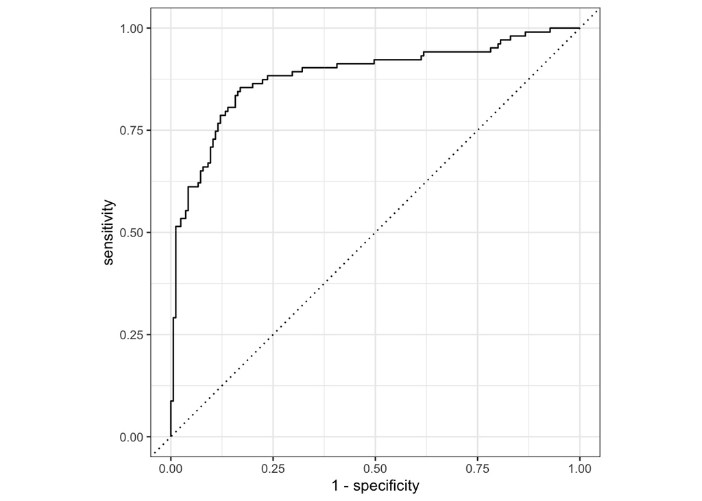

```r
augment(log_fit, new_data = titanic_test) %>%
  roc_curve(survived, .pred_Yes) %>%
  autoplot()
```

#### AUC:

```r
augment(log_fit, new_data = titanic_test) %>%
  roc_auc(survived, .pred_Yes)
```

```
## # A tibble: 1 × 3
##   .metric .estimator .estimate
##   <chr>   <chr>          <dbl>
## 1 roc_auc binary         0.883
```

The logistic regression model performed relatively well it is curved in such a way that indicates a good prediction.

```r
accuracies_compare <- c(log_acc$.estimate, log_acc_test$.estimate)
models_compare <- c("Training Accuracies", "Testing Accuracies")
results_compare <- tibble(accuracies = accuracies_compare, models = models_compare)
results_compare %>%
  arrange(-accuracies_compare)
```

```
## # A tibble: 2 × 2
##   accuracies models
##        <dbl> <chr>
## 1      0.836 Testing Accuracies
## 2      0.812 Training Accuracies
```

The testing and training accuracies differ by 0.0236219. This could be impacted by some unexpected/out of the ordinary occurrences. The sinking of the titanic was a real event, and thus, some people survived against all odds while others died even when they had a higher chance of surviving.